# Practical Machine Learning for Human Activity Recognition

Hong Xu

September 20, 2014

Human activity can be easily monitored by inexpensive devices. Large data are collected and freely available to public. Here we get data from [HAR project](http://groupware.les.inf.puc-rio.br/har). We apply practical machine learning approach to predict human activity type from monitor device data. The machine learning method that we use is **random forest**. We achieve accuracy of 99.9%. And we predict all 20 test cases correctly.

## Data loading

We download the following data from course web site:

- *Training data*: pml-training.csv
- *Test data*: pml-testing.csv

We load data in R using `read.csv()` function.

```r
##### read data
allData <- read.csv("pml-training.csv")
testCase <- read.csv("pml-testing.csv")
```

Training data have 19622 observations of 160 variables. Test data have 20 observations of 160 variables.

## Data pre-processing

Because of its high accuracy, we plan to use **random forest** method to learn the data. Random forest is sensitive to *zero-* or *near zero-variance* predictors. We remove *near zero-variance* variables from both training and test data.

```r
# load library
library(caret)
set.seed(123)

# remove near zero variance columns from both test case and training data
nzCols <- nearZeroVar(testCase)
rmNzTest <- testCase[,-nzCols]
rmNzData <- allData[,-nzCols]
```

Also some variables apparently have no prediction values. We remove the 5 variables from both training and test data to create clean train and test data.

- *X*: row number in column 1.
- *user_name*: user name in column 2.
- *raw_timestamp_part_1*: raw timestamp (part 1) in column 3.
- *raw_timestamp_part_2*: raw timestamp (part 2) in column 4.
- *cvtd_timestamp*: human readable timestamp in column 5.

```r
# remove variables which have no prediction value
# such as record number, user name, record times, record window
clnData <- rmNzData[,-c(1:5)]
clnTest <- rmNzTest[,-c(1:5)]
```

## Data partition

We split the whole training data set into two parts: one for training the model, the othe for evaluating the model. We use 75% of the data for training, the rest 25% for testing.

```r
# split data: 75% for taining, 25% for testing
inTrain <- createDataPartition(y = clnData$classe,
                               p = .75,
                               list = FALSE)
training <- clnData[inTrain,]
testing <- clnData[-inTrain,]
nrow(training)
```

```
## [1] 14718
```

```r
nrow(testing)
```

```
## [1] 4904
```

## Model training

To speed up the training process, we use the parallel computing package `doMC` from [Revolution Analytics](http://revolutionanalytics.com/). To train the model, we use outcome (`classe`) verse all other variables. The in training pre-processing includes the simple normalization techniques: `center` and `scale`.

```r
library(doMC)
registerDoMC(cores = 3)

library(randomForest)
rfFit <- train(classe ~ .,
             data = training,
             method = "rf",
             preProc = c("center", "scale"))
```

The best model is `mtry = 27`, with `accuracy = 0.996` and `Kappa = 0.995`.

```r
rfFit
```

```
## Random Forest
##
## 14718 samples
##    53 predictor
##     5 classes: 'A', 'B', 'C', 'D', 'E'
##
## Pre-processing: centered, scaled
## Resampling: Bootstrapped (25 reps)
##
## Summary of sample sizes: 14718, 14718, 14718, 14718, 14718, 14718, ...
##
## Resampling results across tuning parameters:
##
##   mtry  Accuracy  Kappa  Accuracy SD  Kappa SD
##    2    1         1      0.002        0.002
##   27    1         1      0.001        0.001
##   53    1         1      0.002        0.003
##
## Accuracy was used to select the optimal model using  the largest value.
## The final value used for the model was mtry = 27.
```

We plot the model fitting process below. When number of selected predictor is 27, the accuracy peaks at 0.996.

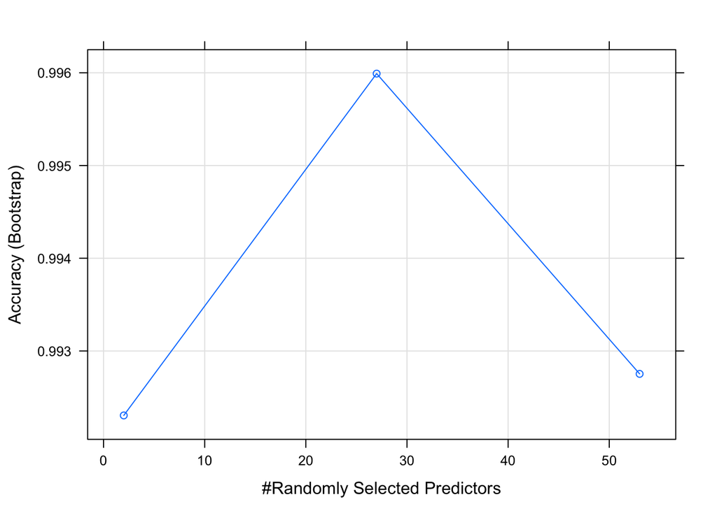

```r
plot(rfFit)
```

## Testing and evaluation

We apply the trained model from above process to the 25% testing data. The prediction result is compared with known classes. The overall accuracy is 0.999. The sensitivity and specificity for each class are larger than 0.99.

```r
##### prediction test
rfClasses <- predict(rfFit, newdata = testing)

# prediction evaluation
cfMtrx <- confusionMatrix(rfClasses, testing$classe)
cfMtrx
```

```
## Confusion Matrix and Statistics
##
##           Reference
## Prediction    A    B    C    D    E
##          A 1395    1    0    0    0
##          B    0  948    1    0    0
##          C    0    0  854    3    0
##          D    0    0    0  801    0
##          E    0    0    0    0  901
##
## Overall Statistics
##
##                Accuracy : 0.999
##                  95% CI : (0.998, 1)
##     No Information Rate : 0.284
##     P-Value [Acc > NIR] : <2e-16
##
##                   Kappa : 0.999
##  Mcnemar's Test P-Value : NA
##
## Statistics by Class:
##
##                      Class: A Class: B Class: C Class: D Class: E
## Sensitivity             1.000    0.999    0.999    0.996    1.000
## Specificity             1.000    1.000    0.999    1.000    1.000
## Pos Pred Value          0.999    0.999    0.996    1.000    1.000
## Neg Pred Value          1.000    1.000    1.000    0.999    1.000
## Prevalence              0.284    0.194    0.174    0.164    0.184
## Detection Rate          0.284    0.193    0.174    0.163    0.184
## Detection Prevalence    0.285    0.194    0.175    0.163    0.184
## Balanced Accuracy       1.000    0.999    0.999    0.998    1.000
```

## Predicting test case

Finally we apply the model to the 20 testing cases. The predicted results are put into files and submitted to the course web site. All the 20 predictions are correct.

```r
##### predict 20 test cases
rfPreds <- predict(rfFit, newdata=clnTest[,-54])
print("The prediction of 20 test cases:")
```

```
## [1] "The prediction of 20 test cases:"
```

```r
rfPreds
```

```
##  [1] B A B A A E D B A A B C B A E E A B B B
## Levels: A B C D E
```

```r
# function to write prediction in file
pml_write_files = function(x){
  n = length(x)
  for(i in 1:n){
    filename = paste0("problem_id_",i,".txt")
    write.table(x[i],file=filename,quote=FALSE,row.names=FALSE,col.names=FALSE)
  }
}

# write prediction in files
pml_write_files(rfPreds)
```